# DATA621_Homework4_JR

Jeyaraman Ramalingam

5/5/2021

## Overview

In this homework assignment, you will explore, analyze and model a data set containing information on approximately 12,000 commercially available wines. The variables are mostly related to the chemical properties of the wine being sold. The response variable is the number of sample cases of wine that were purchased by wine distribution companies after sampling a wine. These cases would be used to provide tasting samples to restaurants and wine stores around the United States. The more sample cases purchased, the more likely is a wine to be sold at a high end restaurant. A large wine manufacturer is studying the data in order to predict the number of wine cases ordered based upon the wine characteristics. If the wine manufacturer can predict the number of cases, then that manufacturer will be able to adjust their wine offering to maximize sales.

## Data Exploration

### Wine Training Data

#### Sample

| TARGET | FixedAcidity | VolatileAcidity | CitricAcid | ResidualSugar | Chlorides | FreeSulfurDioxide | TotalSulfurDioxide | Density | pH | Sulphates | Alcohol | LabelAppeal | AcidIndex | STARS | INDEX |
| --- | --- | --- | --- | --- | --- | --- | --- | --- | --- | --- | --- | --- | --- | --- | --- |
| 3 | 3.2 | 1.160 | -0.98 | 54.2 | -0.567 | NA | 268 | 0.99280 | 3.33 | -0.59 | 9.9 | 0 | 8 | 2 | 1 |
| 3 | 4.5 | 0.160 | -0.81 | 26.1 | -0.425 | 15 | -327 | 1.02792 | 3.38 | 0.70 | NA | -1 | 7 | 3 | 2 |
| 5 | 7.1 | 2.640 | -0.88 | 14.8 | 0.037 | 214 | 142 | 0.99518 | 3.12 | 0.48 | 22.0 | -1 | 8 | 3 | 4 |
| 3 | 5.7 | 0.385 | 0.04 | 18.8 | -0.425 | 22 | 115 | 0.99640 | 2.24 | 1.83 | 6.2 | -1 | 6 | 1 | 5 |
| 4 | 8.0 | 0.330 | -1.26 | 9.4 | NA | -167 | 108 | 0.99457 | 3.12 | 1.77 | 13.7 | 0 | 9 | 2 | 6 |
| 0 | 11.3 | 0.320 | 0.59 | 2.2 | 0.556 | -37 | 15 | 0.99940 | 3.20 | 1.29 | 15.4 | 0 | 11 | NA | 7 |

#### Input Dataset Summaries

```
##      TARGET       FixedAcidity     VolatileAcidity     CitricAcid
##  Min.   :0.000   Min.   :-18.100   Min.   :-2.7900   Min.   :-3.2400
##  1st Qu.:2.000   1st Qu.:  5.200   1st Qu.: 0.1300   1st Qu.: 0.0300
##  Median :3.000   Median :  6.900   Median : 0.2800   Median : 0.3100
##  Mean   :3.029   Mean   :  7.076   Mean   : 0.3241   Mean   : 0.3084
##  3rd Qu.:4.000   3rd Qu.:  9.500   3rd Qu.: 0.6400   3rd Qu.: 0.5800
##  Max.   :8.000   Max.   : 34.400   Max.   : 3.6800   Max.   : 3.8600
##
##  ResidualSugar        Chlorides       FreeSulfurDioxide TotalSulfurDioxide
##  Min.   :-127.800   Min.   :-1.1710   Min.   :-555.00   Min.   :-823.0
##  1st Qu.:  -2.000   1st Qu.:-0.0310   1st Qu.:   0.00   1st Qu.:  27.0
##  Median :   3.900   Median : 0.0460   Median :  30.00   Median : 123.0
##  Mean   :   5.419   Mean   : 0.0548   Mean   :  30.85   Mean   : 120.7
##  3rd Qu.:  15.900   3rd Qu.: 0.1530   3rd Qu.:  70.00   3rd Qu.: 208.0
##  Max.   : 141.150   Max.   : 1.3510   Max.   : 623.00   Max.   :1057.0
##  NA's   :616        NA's   :638       NA's   :647       NA's   :682
##     Density             pH          Sulphates          Alcohol
##  Min.   :0.8881   Min.   :0.480   Min.   :-3.1300   Min.   :-4.70
##  1st Qu.:0.9877   1st Qu.:2.960   1st Qu.: 0.2800   1st Qu.: 9.00
##  Median :0.9945   Median :3.200   Median : 0.5000   Median :10.40
##  Mean   :0.9942   Mean   :3.208   Mean   : 0.5271   Mean   :10.49
##  3rd Qu.:1.0005   3rd Qu.:3.470   3rd Qu.: 0.8600   3rd Qu.:12.40
##  Max.   :1.0992   Max.   :6.130   Max.   : 4.2400   Max.   :26.50
##                   NA's   :395     NA's   :1210      NA's   :653
##   LabelAppeal          AcidIndex          STARS           INDEX
##  Min.   :-2.000000   Min.   : 4.000   Min.   :1.000   Min.   :    1
##  1st Qu.:-1.000000   1st Qu.: 7.000   1st Qu.:1.000   1st Qu.: 4038
##  Median : 0.000000   Median : 8.000   Median :2.000   Median : 8110
##  Mean   :-0.009066   Mean   : 7.773   Mean   :2.042   Mean   : 8070
##  3rd Qu.: 1.000000   3rd Qu.: 8.000   3rd Qu.:3.000   3rd Qu.:12106
##  Max.   : 2.000000   Max.   :17.000   Max.   :4.000   Max.   :16129
##                                       NA's   :3359
```

#### Missing Data Check

```
##             TARGET       FixedAcidity    VolatileAcidity         CitricAcid
##                  0                  0                  0                  0
##      ResidualSugar          Chlorides  FreeSulfurDioxide TotalSulfurDioxide
##                616                638                647                682
##            Density                 pH          Sulphates            Alcohol
##                  0                395               1210                653
##        LabelAppeal          AcidIndex              STARS              INDEX
##                  0                  0               3359                  0
```

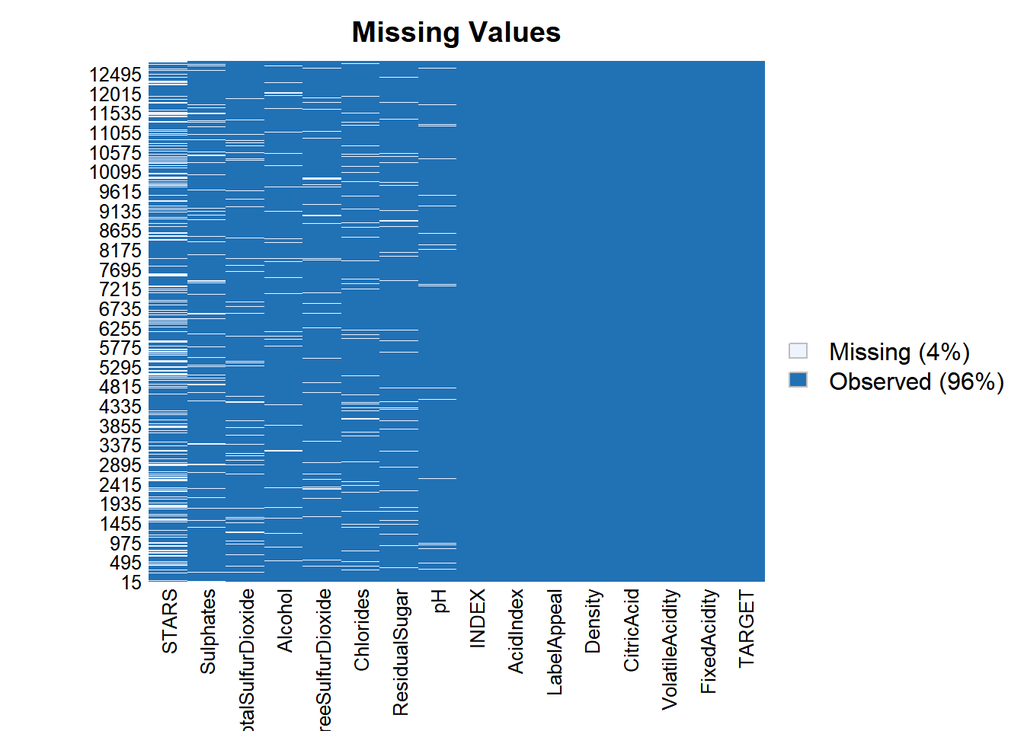

### Wine Evaluation Data

#### Sample

| INDEX | TARGET | FixedAcidity | VolatileAcidity | CitricAcid | ResidualSugar | Chlorides | FreeSulfurDioxide | TotalSulfurDioxide | Density | pH | Sulphates | Alcohol | LabelAppeal | AcidIndex | STARS |
| --- | --- | --- | --- | --- | --- | --- | --- | --- | --- | --- | --- | --- | --- | --- | --- |
| 3 | NA | 5.4 | -0.860 | 0.27 | -10.7 | 0.092 | 23 | 398 | 0.98527 | 5.02 | 0.64 | 12.30 | -1 | 6 | NA |
| 9 | NA | 12.4 | 0.385 | -0.76 | -19.7 | 1.169 | -37 | 68 | 0.99048 | 3.37 | 1.09 | 16.00 | 0 | 6 | 2 |
| 10 | NA | 7.2 | 1.750 | 0.17 | -33.0 | 0.065 | 9 | 76 | 1.04641 | 4.61 | 0.68 | 8.55 | 0 | 8 | 1 |
| 18 | NA | 6.2 | 0.100 | 1.80 | 1.0 | -0.179 | 104 | 89 | 0.98877 | 3.20 | 2.11 | 12.30 | -1 | 8 | 1 |
| 21 | NA | 11.4 | 0.210 | 0.28 | 1.2 | 0.038 | 70 | 53 | 1.02899 | 2.54 | -0.07 | 4.80 | 0 | 10 | NA |
| 30 | NA | 17.6 | 0.040 | -1.15 | 1.4 | 0.535 | -250 | 140 | 0.95028 | 3.06 | -0.02 | 11.40 | 1 | 8 | 4 |

#### Input Dataset Summaries

```
##      INDEX        TARGET         FixedAcidity     VolatileAcidity
##  Min.   :    3   Mode:logical   Min.   :-18.200   Min.   :-2.8300
##  1st Qu.: 4018   NA's:3335      1st Qu.:  5.200   1st Qu.: 0.0800
##  Median : 7906                  Median :  6.900   Median : 0.2800
##  Mean   : 8048                  Mean   :  6.864   Mean   : 0.3103
##  3rd Qu.:12061                  3rd Qu.:  9.000   3rd Qu.: 0.6300
##  Max.   :16130                  Max.   : 33.500   Max.   : 3.6100
##
##    CitricAcid      ResidualSugar        Chlorides        FreeSulfurDioxide
##  Min.   :-3.1200   Min.   :-128.300   Min.   :-1.15000   Min.   :-563.00
##  1st Qu.: 0.0000   1st Qu.:  -2.600   1st Qu.: 0.01600   1st Qu.:   3.00
##  Median : 0.3100   Median :   3.600   Median : 0.04700   Median :  30.00
##  Mean   : 0.3124   Mean   :   5.319   Mean   : 0.06143   Mean   :  34.95
##  3rd Qu.: 0.6050   3rd Qu.:  17.200   3rd Qu.: 0.17100   3rd Qu.:  79.25
##  Max.   : 3.7600   Max.   : 145.400   Max.   : 1.26300   Max.   : 617.00
##                    NA's   :168        NA's   :138        NA's   :152
##  TotalSulfurDioxide    Density             pH          Sulphates
##  Min.   :-769.00    Min.   :0.8898   Min.   :0.600   Min.   :-3.0700
##  1st Qu.:  27.25    1st Qu.:0.9883   1st Qu.:2.980   1st Qu.: 0.3300
##  Median : 124.00    Median :0.9946   Median :3.210   Median : 0.5000
##  Mean   : 123.41    Mean   :0.9947   Mean   :3.237   Mean   : 0.5346
##  3rd Qu.: 210.00    3rd Qu.:1.0005   3rd Qu.:3.490   3rd Qu.: 0.8200
##  Max.   :1004.00    Max.   :1.0998   Max.   :6.210   Max.   : 4.1800
##  NA's   :157                         NA's   :104     NA's   :310
##     Alcohol       LabelAppeal         AcidIndex          STARS
##  Min.   :-4.20   Min.   :-2.00000   Min.   : 5.000   Min.   :1.00
##  1st Qu.: 9.00   1st Qu.:-1.00000   1st Qu.: 7.000   1st Qu.:1.00
##  Median :10.40   Median : 0.00000   Median : 8.000   Median :2.00
##  Mean   :10.58   Mean   : 0.01349   Mean   : 7.748   Mean   :2.04
##  3rd Qu.:12.50   3rd Qu.: 1.00000   3rd Qu.: 8.000   3rd Qu.:3.00
##  Max.   :25.60   Max.   : 2.00000   Max.   :17.000   Max.   :4.00
##  NA's   :185                                         NA's   :841
```

#### Missing Data Check

```
##              INDEX             TARGET       FixedAcidity    VolatileAcidity
##                  0               3335                  0                  0
##         CitricAcid      ResidualSugar          Chlorides  FreeSulfurDioxide
##                  0                168                138                152
## TotalSulfurDioxide            Density                 pH          Sulphates
##                157                  0                104                310
##            Alcohol        LabelAppeal          AcidIndex              STARS
##                185                  0                  0                841
```

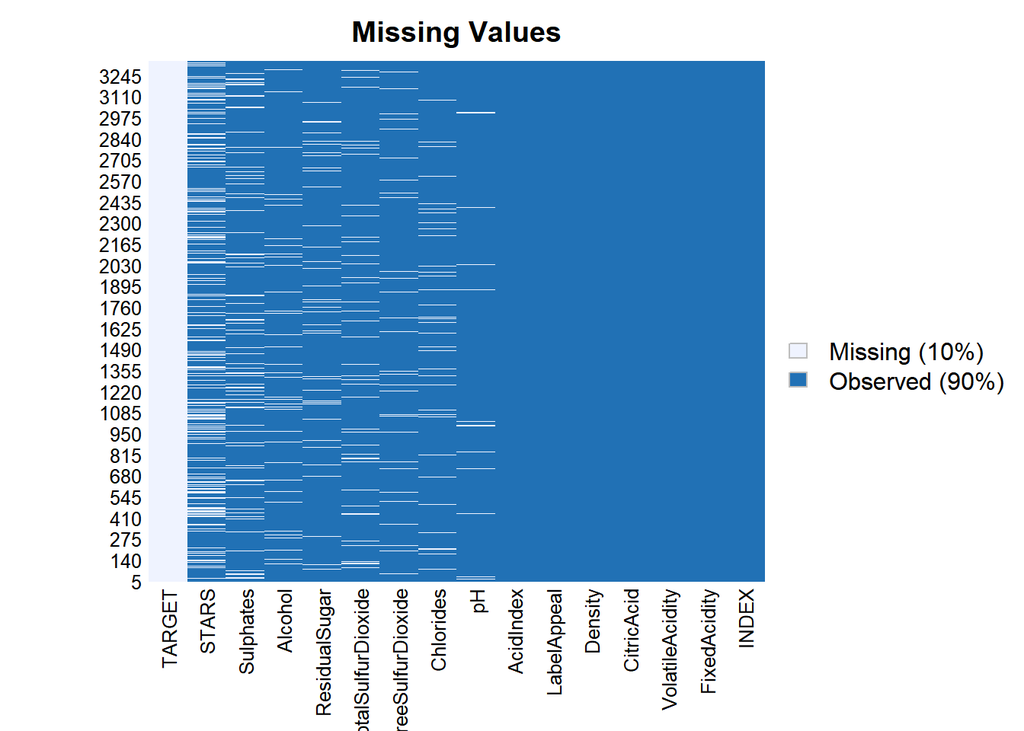

### Findings

The findings from Data Exploration on Training and Evaluation dataset are below.

1. Imputation needs to be done for the missing values.

We will perform all of these exercises in the Data Preparation step.

## Data Preparation

### Training Data - Missing Data Re-test

```
##             TARGET       FixedAcidity    VolatileAcidity         CitricAcid
##                  0                  0                  0                  0
##      ResidualSugar          Chlorides  FreeSulfurDioxide TotalSulfurDioxide
##                  0                  0                  0                  0
##            Density                 pH          Sulphates            Alcohol
##                  0                  0                  0                  0
##        LabelAppeal          AcidIndex              STARS              INDEX
##                  0                  0                  0                  0
```

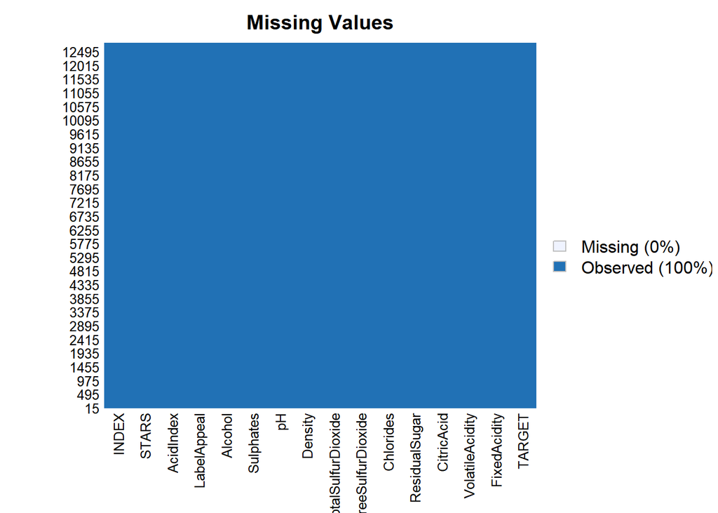

### Training Data - Summary

|  | TARGET | FixedAcidity | VolatileAcidity | CitricAcid | ResidualSugar | Chlorides | FreeSulfurDioxide | TotalSulfurDioxide | Density | pH | Sulphates | Alcohol | LabelAppeal | AcidIndex | STARS | INDEX |
| --- | --- | --- | --- | --- | --- | --- | --- | --- | --- | --- | --- | --- | --- | --- | --- | --- |
|  | Min. :0.000 | Min. :-18.100 | Min. :-2.7900 | Min. :-3.2400 | Min. :-127.800 | Min. :-1.17100 | Min. :-555.00 | Min. :-823.0 | Min. :0.8881 | Min. :0.480 | Min. :-3.1300 | Min. :-4.70 | Min. :-2.000000 | Min. : 4.000 | Min. :1.000 | Min. : 1 |
|  | 1st Qu.:2.000 | 1st Qu.: 5.200 | 1st Qu.: 0.1300 | 1st Qu.: 0.0300 | 1st Qu.: -2.400 | 1st Qu.:-0.02900 | 1st Qu.: -0.50 | 1st Qu.: 27.0 | 1st Qu.:0.9877 | 1st Qu.:2.960 | 1st Qu.: 0.2800 | 1st Qu.: 9.00 | 1st Qu.:-1.000000 | 1st Qu.: 7.000 | 1st Qu.:1.000 | 1st Qu.: 4038 |
|  | Median :3.000 | Median : 6.900 | Median : 0.2800 | Median : 0.3100 | Median : 3.800 | Median : 0.04600 | Median : 30.00 | Median : 123.0 | Median :0.9945 | Median :3.200 | Median : 0.5000 | Median :10.40 | Median : 0.000000 | Median : 8.000 | Median :2.000 | Median : 8110 |
|  | Mean :3.029 | Mean : 7.076 | Mean : 0.3241 | Mean : 0.3084 | Mean : 5.327 | Mean : 0.05471 | Mean : 30.83 | Mean : 120.5 | Mean :0.9942 | Mean :3.207 | Mean : 0.5259 | Mean :10.49 | Mean :-0.009066 | Mean : 7.773 | Mean :1.865 | Mean : 8070 |
|  | 3rd Qu.:4.000 | 3rd Qu.: 9.500 | 3rd Qu.: 0.6400 | 3rd Qu.: 0.5800 | 3rd Qu.: 15.800 | 3rd Qu.: 0.15200 | 3rd Qu.: 70.00 | 3rd Qu.: 208.0 | 3rd Qu.:1.0005 | 3rd Qu.:3.470 | 3rd Qu.: 0.8500 | 3rd Qu.:12.40 | 3rd Qu.: 1.000000 | 3rd Qu.: 8.000 | 3rd Qu.:2.000 | 3rd Qu.:12106 |
|  | Max. :8.000 | Max. : 34.400 | Max. : 3.6800 | Max. : 3.8600 | Max. : 141.150 | Max. : 1.35100 | Max. : 623.00 | Max. :1057.0 | Max. :1.0992 | Max. :6.130 | Max. : 4.2400 | Max. :26.50 | Max. : 2.000000 | Max. :17.000 | Max. :4.000 | Max. :16129 |

### Training Data - Histograms

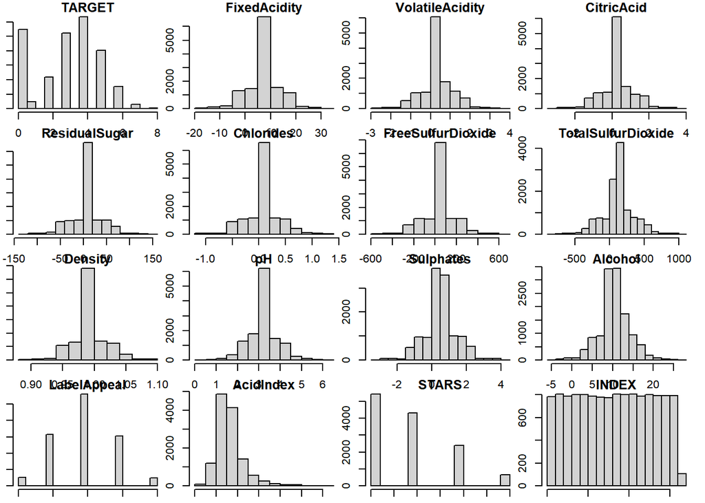

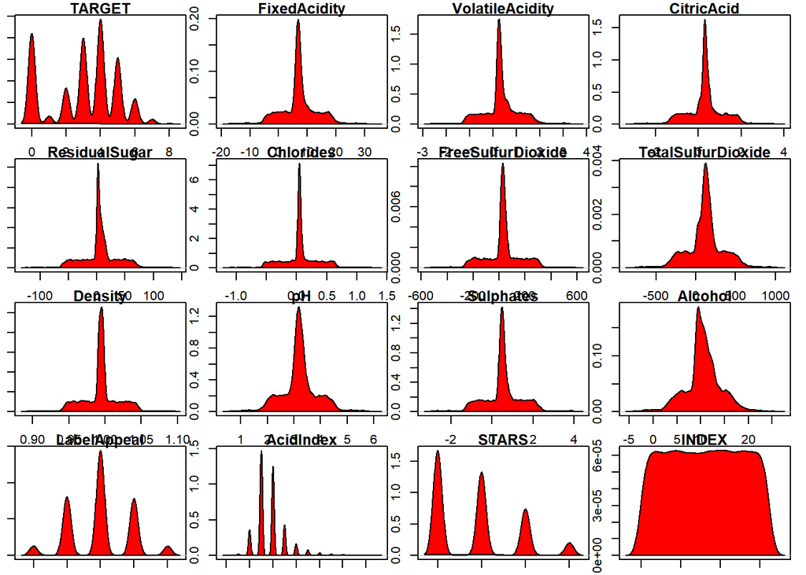

### Training Data - Skewness Report

```
##             TARGET       FixedAcidity    VolatileAcidity         CitricAcid
##      -0.3263010393      -0.0225859614       0.0203799653      -0.0503070404
##      ResidualSugar          Chlorides  FreeSulfurDioxide TotalSulfurDioxide
##      -0.0512471612       0.0263063156      -0.0026622703      -0.0200435430
##            Density                 pH          Sulphates            Alcohol
##      -0.0186937639       0.0468284584       0.0003559448      -0.0296366141
##        LabelAppeal          AcidIndex              STARS              INDEX
##       0.0084294570       1.6484959453       0.6953852521      -0.0032496204
```

### Training Data - Correlation Report

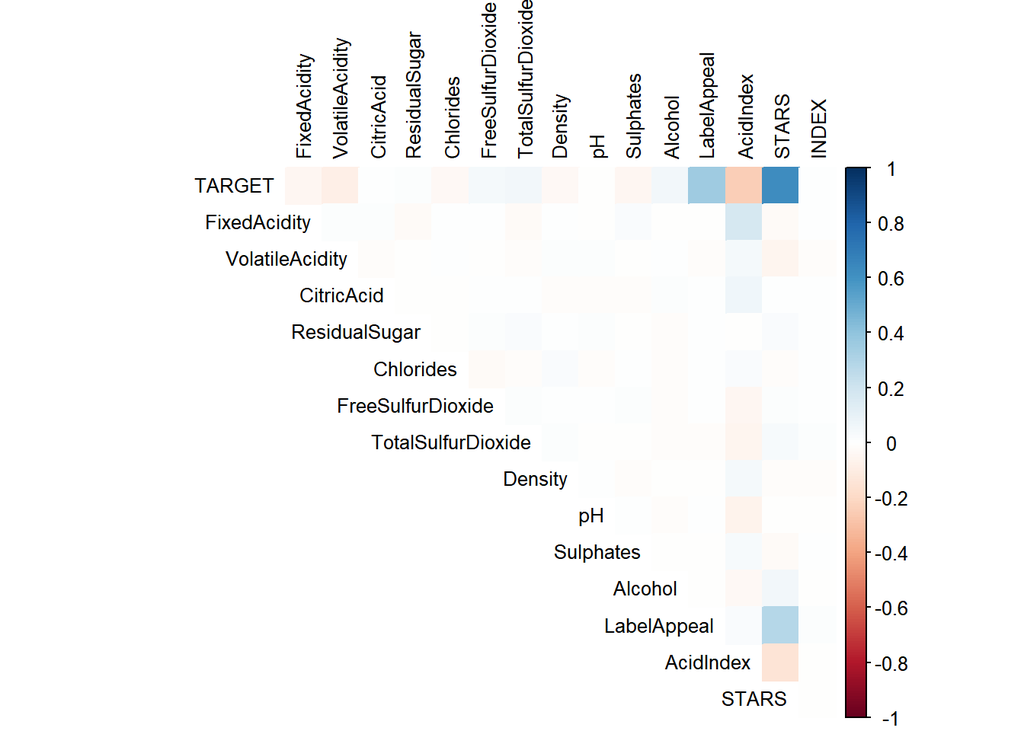

### Evaluation Data - Missing Data Re-test

```
##              INDEX             TARGET       FixedAcidity    VolatileAcidity
##                  0                  0                  0                  0
##         CitricAcid      ResidualSugar          Chlorides  FreeSulfurDioxide
##                  0                  0                  0                  0
## TotalSulfurDioxide            Density                 pH          Sulphates
##                  0                  0                  0                  0
##            Alcohol        LabelAppeal          AcidIndex              STARS
##                  0                  0                  0                  0
```

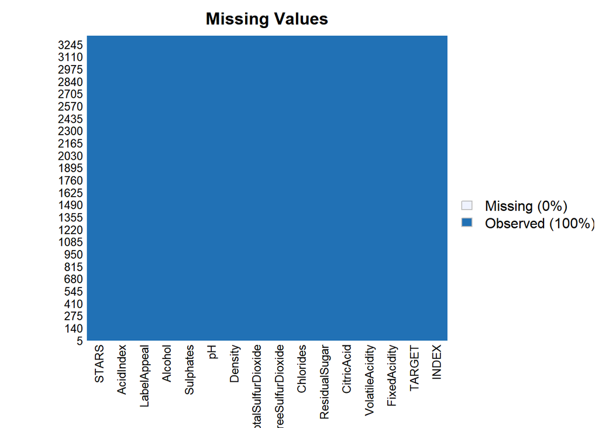

### Evaluation Data - Summary

|  | INDEX | TARGET | FixedAcidity | VolatileAcidity | CitricAcid | ResidualSugar | Chlorides | FreeSulfurDioxide | TotalSulfurDioxide | Density | pH | Sulphates | Alcohol | LabelAppeal | AcidIndex | STARS |
| --- | --- | --- | --- | --- | --- | --- | --- | --- | --- | --- | --- | --- | --- | --- | --- | --- |
|  | Min. : 3 | Min. :0 | Min. :-18.200 | Min. :-2.8300 | Min. :-3.1200 | Min. :-128.300 | Min. :-1.15000 | Min. :-563.00 | Min. :-769 | Min. :0.8898 | Min. :0.600 | Min. :-3.0700 | Min. :-4.20 | Min. :-2.00000 | Min. : 5.000 | Min. :1.000 |
|  | 1st Qu.: 4018 | 1st Qu.:0 | 1st Qu.: 5.200 | 1st Qu.: 0.0800 | 1st Qu.: 0.0000 | 1st Qu.: -2.450 | 1st Qu.: 0.01400 | 1st Qu.: 3.00 | 1st Qu.: 27 | 1st Qu.:0.9883 | 1st Qu.:2.980 | 1st Qu.: 0.3300 | 1st Qu.: 9.00 | 1st Qu.:-1.00000 | 1st Qu.: 7.000 | 1st Qu.:1.000 |
|  | Median : 7906 | Median :0 | Median : 6.900 | Median : 0.2800 | Median : 0.3100 | Median : 3.600 | Median : 0.04700 | Median : 29.00 | Median : 124 | Median :0.9946 | Median :3.210 | Median : 0.5000 | Median :10.40 | Median : 0.00000 | Median : 8.000 | Median :2.000 |
|  | Mean : 8048 | Mean :0 | Mean : 6.864 | Mean : 0.3103 | Mean : 0.3124 | Mean : 5.468 | Mean : 0.06211 | Mean : 34.99 | Mean : 124 | Mean :0.9947 | Mean :3.236 | Mean : 0.5372 | Mean :10.58 | Mean : 0.01349 | Mean : 7.748 | Mean :2.026 |
|  | 3rd Qu.:12061 | 3rd Qu.:0 | 3rd Qu.: 9.000 | 3rd Qu.: 0.6300 | 3rd Qu.: 0.6050 | 3rd Qu.: 17.750 | 3rd Qu.: 0.17200 | 3rd Qu.: 79.00 | 3rd Qu.: 210 | 3rd Qu.:1.0005 | 3rd Qu.:3.490 | 3rd Qu.: 0.8200 | 3rd Qu.:12.50 | 3rd Qu.: 1.00000 | 3rd Qu.: 8.000 | 3rd Qu.:3.000 |
|  | Max. :16130 | Max. :0 | Max. : 33.500 | Max. : 3.6100 | Max. : 3.7600 | Max. : 145.400 | Max. : 1.26300 | Max. : 617.00 | Max. :1004 | Max. :1.0998 | Max. :6.210 | Max. : 4.1800 | Max. :25.60 | Max. : 2.00000 | Max. :17.000 | Max. :4.000 |

### Evaluation Data - Histograms

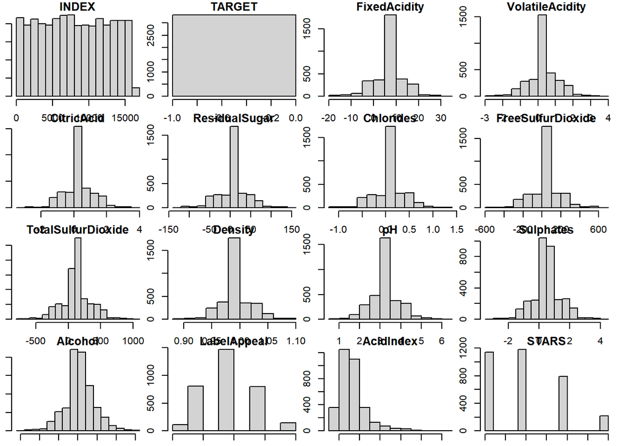

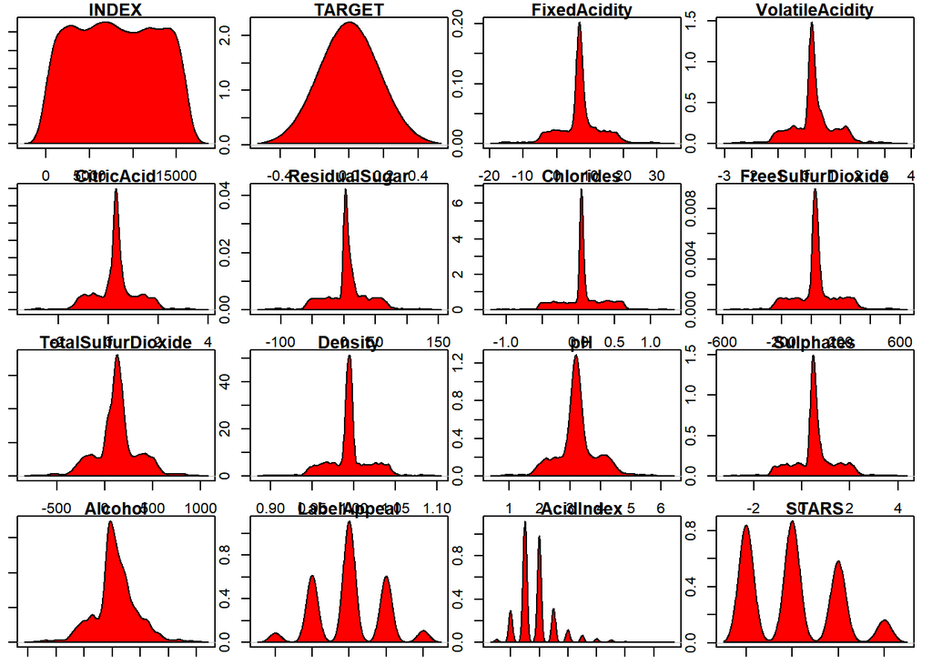

### Evaluation Data - Skewness Report

```
##              INDEX             TARGET       FixedAcidity    VolatileAcidity
##         0.01246970                NaN        -0.11724599        -0.04373012
##         CitricAcid      ResidualSugar          Chlorides  FreeSulfurDioxide
##        -0.02848982        -0.03758196        -0.03085765         0.11367334
## TotalSulfurDioxide            Density                 pH          Sulphates
##        -0.03218766        -0.02965927         0.11955481         0.02146845
##            Alcohol        LabelAppeal          AcidIndex              STARS
##         0.04071630         0.04548870         1.50665887         0.45648643
```

### Evaluation Data - Correlation Report

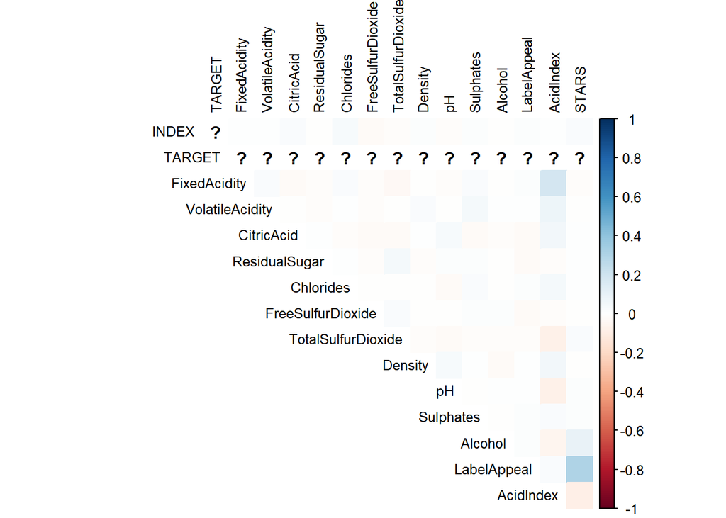

## Data Models

### Model Preparation

1. Poisson Regression - > TARGET and other variables
2. Zero Inflated Poisson - > TARGET and other variables
3. Negative Binomial - > TARGET and other variables
4. Linear Regression - > TARGET and other variables
5. Linear Regression - > TARGET and STARS
6. Step Wise Regression (Backward) -> TARGET and STARS
7. Linear Regression -> TARGET and Derived Variable

### Poisson Regression Model

Poisson Regression models are best used for modeling events where the outcomes are counts. Or, more specifically, count data: discrete data with non-negative integer values that count something, like the number of times an event occurs during a given timeframe or the number of people in line at the grocery store.

```
##
## Call:
## glm(formula = TARGET ~ ., family = poisson, data = train2)
##
## Deviance Residuals:
##     Min       1Q   Median       3Q      Max
## -2.9240  -0.6693   0.1263   0.6294   2.4161
##
## Coefficients:
##                      Estimate Std. Error z value Pr(>|z|)
## (Intercept)         1.638e+00  2.184e-01   7.501 6.32e-14 ***
## FixedAcidity       -1.701e-04  9.122e-04  -0.186 0.852071
## VolatileAcidity    -3.845e-02  7.233e-03  -5.316 1.06e-07 ***
## CitricAcid          1.307e-02  6.589e-03   1.984 0.047303 *
## ResidualSugar      -2.391e-05  1.678e-04  -0.143 0.886666
## Chlorides          -4.572e-02  1.811e-02  -2.525 0.011567 *
## FreeSulfurDioxide   1.323e-04  3.852e-05   3.436 0.000591 ***
## TotalSulfurDioxide  9.098e-05  2.462e-05   3.696 0.000219 ***
## Density            -4.065e-01  2.141e-01  -1.898 0.057646 .
## pH                 -1.762e-02  8.375e-03  -2.104 0.035420 *
## Sulphates          -1.400e-02  6.102e-03  -2.294 0.021779 *
## Alcohol             2.996e-03  1.540e-03   1.946 0.051694 .
## LabelAppeal         1.556e-01  6.745e-03  23.067  < 2e-16 ***
## AcidIndex          -1.022e-01  5.075e-03 -20.141  < 2e-16 ***
## STARS               3.309e-01  6.260e-03  52.861  < 2e-16 ***
## INDEX              -4.166e-07  1.222e-06  -0.341 0.733139
## ---
## Signif. codes:  0 '***' 0.001 '**' 0.01 '*' 0.05 '.' 0.1 ' ' 1
##
## (Dispersion parameter for poisson family taken to be 1)
##
##     Null deviance: 18288  on 10237  degrees of freedom
## Residual deviance: 12781  on 10222  degrees of freedom
## AIC: 38368
##
## Number of Fisher Scoring iterations: 5
```

### Poisson Regression Model Prediction Metrics

Test dataset is used for predicting the output and the confusion matrix is used for comparing the output parameters.

```
## Confusion Matrix and Statistics
##
##           Reference
## Prediction   1   0
##          1  47 546
##          0   0   0
##
##                Accuracy : 0.0793
##                  95% CI : (0.0588, 0.104)
##     No Information Rate : 0.9207
##     P-Value [Acc > NIR] : 1
##
##                   Kappa : 0
##
##  Mcnemar's Test P-Value : <2e-16
##
##             Sensitivity : 1.00000
##             Specificity : 0.00000
##          Pos Pred Value : 0.07926
##          Neg Pred Value :     NaN
##              Prevalence : 0.07926
##          Detection Rate : 0.07926
##    Detection Prevalence : 1.00000
##       Balanced Accuracy : 0.50000
##
##        'Positive' Class : 1
##
```

Accuracy of the Model 1 is 7.9%

### Zero Inflated Poisson

Zero-inflated poisson regression is used to model count data that has an excess of zero counts

```
##
## Call:
## zeroinfl(formula = TARGET ~ ., data = train2)
##
## Pearson residuals:
##      Min       1Q   Median       3Q      Max
## -2.03381 -0.45726  0.02771  0.43862  3.78163
##
## Count model coefficients (poisson with log link):
##                      Estimate Std. Error z value Pr(>|z|)
## (Intercept)         1.523e+00         NA      NA       NA
## FixedAcidity        2.549e-04         NA      NA       NA
## VolatileAcidity    -1.410e-02         NA      NA       NA
## CitricAcid         -3.620e-04         NA      NA       NA
## ResidualSugar      -8.020e-05         NA      NA       NA
## Chlorides          -1.860e-02         NA      NA       NA
## FreeSulfurDioxide   2.243e-05         NA      NA       NA
## TotalSulfurDioxide -1.786e-05         NA      NA       NA
## Density            -4.131e-01         NA      NA       NA
## pH                  2.770e-03         NA      NA       NA
## Sulphates           5.056e-04         NA      NA       NA
## Alcohol             7.421e-03         NA      NA       NA
## LabelAppeal         2.395e-01         NA      NA       NA
## AcidIndex          -1.998e-02         NA      NA       NA
## STARS               1.182e-01         NA      NA       NA
## INDEX              -2.326e-07         NA      NA       NA
##
## Zero-inflation model coefficients (binomial with logit link):
##                      Estimate Std. Error z value Pr(>|z|)
## (Intercept)        -2.297e+00         NA      NA       NA
## FixedAcidity        2.150e-03         NA      NA       NA
## VolatileAcidity     1.837e-01         NA      NA       NA
## CitricAcid         -7.582e-02         NA      NA       NA
## ResidualSugar      -5.788e-04         NA      NA       NA
## Chlorides           1.804e-01         NA      NA       NA
## FreeSulfurDioxide  -9.633e-04         NA      NA       NA
## TotalSulfurDioxide -8.302e-04         NA      NA       NA
## Density             5.357e-01         NA      NA       NA
## pH                  1.588e-01         NA      NA       NA
## Sulphates           1.235e-01         NA      NA       NA
## Alcohol             2.407e-02         NA      NA       NA
## LabelAppeal         6.404e-01         NA      NA       NA
## AcidIndex           4.595e-01         NA      NA       NA
## STARS              -3.038e+00         NA      NA       NA
## INDEX               8.134e-06         NA      NA       NA
##
## Number of iterations in BFGS optimization: 40
## Log-likelihood: -1.684e+04 on 32 Df
```

### Vuong Test

The Vuong non-nested test is based on a comparison of the predicted probabilities of two models that do not nest. Examples include comparisons of zero-inflated count models with their non-zero-inflated analogs (e.g., zero-inflated Poisson versus ordinary Poisson, or zero-inflated negative-binomial versus ordinary negative-binomial).

```
## Vuong Non-Nested Hypothesis Test-Statistic:
## (test-statistic is asymptotically distributed N(0,1) under the
##  null that the models are indistinguishible)
## -------------------------------------------------------------
##               Vuong z-statistic             H_A    p-value
## Raw                   -39.31921 model2 > model1 < 2.22e-16
## AIC-corrected         -39.04853 model2 > model1 < 2.22e-16
## BIC-corrected         -38.06953 model2 > model1 < 2.22e-16
```

As a result of Vuong test , Model 2 performs better

### Zero Inflated Poisson Prediction Metrics

Test dataset is used for predicting the output and the confusion matrix is used for comparing the output parameters.

```
## Confusion Matrix and Statistics
##
##           Reference
## Prediction   1   0
##          1  47 501
##          0   0  45
##
##                Accuracy : 0.1551
##                  95% CI : (0.1269, 0.1868)
##     No Information Rate : 0.9207
##     P-Value [Acc > NIR] : 1
##
##                   Kappa : 0.014
##
##  Mcnemar's Test P-Value : <2e-16
##
##             Sensitivity : 1.00000
##             Specificity : 0.08242
##          Pos Pred Value : 0.08577
##          Neg Pred Value : 1.00000
##              Prevalence : 0.07926
##          Detection Rate : 0.07926
##    Detection Prevalence : 0.92411
##       Balanced Accuracy : 0.54121
##
##        'Positive' Class : 1
##
```

Accuracy of the Model 2 is 15%

### Negative Binomial

Negative binomial regression is for modeling count variables, usually for over-dispersed count outcome variables.

```
##
## Call:
## glm.nb(formula = TARGET ~ ., data = train2, init.theta = 49062.685,
##     link = log)
##
## Deviance Residuals:
##     Min       1Q   Median       3Q      Max
## -2.9240  -0.6693   0.1263   0.6294   2.4160
##
## Coefficients:
##                      Estimate Std. Error z value Pr(>|z|)
## (Intercept)         1.638e+00  2.184e-01   7.501 6.33e-14 ***
## FixedAcidity       -1.701e-04  9.122e-04  -0.186 0.852076
## VolatileAcidity    -3.845e-02  7.233e-03  -5.316 1.06e-07 ***
## CitricAcid          1.307e-02  6.589e-03   1.984 0.047309 *
## ResidualSugar      -2.391e-05  1.678e-04  -0.142 0.886692
## Chlorides          -4.572e-02  1.811e-02  -2.525 0.011568 *
## FreeSulfurDioxide   1.324e-04  3.852e-05   3.436 0.000591 ***
## TotalSulfurDioxide  9.098e-05  2.462e-05   3.696 0.000219 ***
## Density            -4.065e-01  2.142e-01  -1.898 0.057652 .
## pH                 -1.762e-02  8.375e-03  -2.104 0.035420 *
## Sulphates          -1.400e-02  6.103e-03  -2.294 0.021780 *
## Alcohol             2.995e-03  1.540e-03   1.946 0.051703 .
## LabelAppeal         1.556e-01  6.745e-03  23.066  < 2e-16 ***
## AcidIndex          -1.022e-01  5.075e-03 -20.141  < 2e-16 ***
## STARS               3.309e-01  6.260e-03  52.859  < 2e-16 ***
## INDEX              -4.166e-07  1.222e-06  -0.341 0.733124
## ---
## Signif. codes:  0 '***' 0.001 '**' 0.01 '*' 0.05 '.' 0.1 ' ' 1
##
## (Dispersion parameter for Negative Binomial(49062.68) family taken to be 1)
##
##     Null deviance: 18287  on 10237  degrees of freedom
## Residual deviance: 12780  on 10222  degrees of freedom
## AIC: 38370
##
## Number of Fisher Scoring iterations: 1
##
##
##               Theta:  49063
##           Std. Err.:  63225
## Warning while fitting theta: iteration limit reached
##
##  2 x log-likelihood:  -38335.86
```

### Negative Binomial Prediction Metrics

Test dataset is used for predicting the output and the confusion matrix is used for comparing the output parameters.

```
## Confusion Matrix and Statistics
##
##           Reference
## Prediction   1   0
##          1  47 546
##          0   0   0
##
##                Accuracy : 0.0793
##                  95% CI : (0.0588, 0.104)
##     No Information Rate : 0.9207
##     P-Value [Acc > NIR] : 1
##
##                   Kappa : 0
##
##  Mcnemar's Test P-Value : <2e-16
##
##             Sensitivity : 1.00000
##             Specificity : 0.00000
##          Pos Pred Value : 0.07926
##          Neg Pred Value :     NaN
##              Prevalence : 0.07926
##          Detection Rate : 0.07926
##    Detection Prevalence : 1.00000
##       Balanced Accuracy : 0.50000
##
##        'Positive' Class : 1
##
```

### Linear Regression Model (All Variables)

Linear regression attempts to model the relationship between two variables by fitting a linear equation to observed data. … A linear regression line has an equation of the form Y = a + bX, where X is the explanatory variable and Y is the dependent variable.

```
##
## Call:
## lm(formula = TARGET ~ ., data = train2)
##
## Residuals:
##     Min      1Q  Median      3Q     Max
## -4.3372 -0.9989  0.1670  1.0261  4.0142
##
## Coefficients:
##                      Estimate Std. Error t value Pr(>|t|)
## (Intercept)         4.079e+00  5.350e-01   7.625 2.66e-14 ***
## FixedAcidity       -9.806e-05  2.238e-03  -0.044 0.965058
## VolatileAcidity    -1.150e-01  1.778e-02  -6.464 1.06e-10 ***
## CitricAcid          3.696e-02  1.621e-02   2.279 0.022674 *
## ResidualSugar      -3.910e-05  4.115e-04  -0.095 0.924304
## Chlorides          -1.387e-01  4.413e-02  -3.144 0.001674 **
## FreeSulfurDioxide   3.807e-04  9.477e-05   4.017 5.94e-05 ***
## TotalSulfurDioxide  2.499e-04  6.015e-05   4.154 3.29e-05 ***
## Density            -1.180e+00  5.258e-01  -2.245 0.024807 *
## pH                 -4.067e-02  2.059e-02  -1.975 0.048277 *
## Sulphates          -3.693e-02  1.501e-02  -2.460 0.013909 *
## Alcohol             1.339e-02  3.765e-03   3.557 0.000377 ***
## LabelAppeal         4.737e-01  1.636e-02  28.958  < 2e-16 ***
## AcidIndex          -2.540e-01  1.102e-02 -23.052  < 2e-16 ***
## STARS               1.136e+00  1.666e-02  68.217  < 2e-16 ***
## INDEX              -1.736e-06  3.004e-06  -0.578 0.563393
## ---
## Signif. codes:  0 '***' 0.001 '**' 0.01 '*' 0.05 '.' 0.1 ' ' 1
##
## Residual standard error: 1.414 on 10222 degrees of freedom
## Multiple R-squared:  0.4614, Adjusted R-squared:  0.4606
## F-statistic: 583.7 on 15 and 10222 DF,  p-value: < 2.2e-16
```

### Linear Regression (All Variables) Prediction Metrics

Test dataset is used for predicting the output and the confusion matrix is used for comparing the output parameters.

```
## Confusion Matrix and Statistics
##
##           Reference
## Prediction   1   0
##          1  46 531
##          0   1  15
##
##                Accuracy : 0.1029
##                  95% CI : (0.0796, 0.1302)
##     No Information Rate : 0.9207
##     P-Value [Acc > NIR] : 1
##
##                   Kappa : 0.001
##
##  Mcnemar's Test P-Value : <2e-16
##
##             Sensitivity : 0.97872
##             Specificity : 0.02747
##          Pos Pred Value : 0.07972
##          Neg Pred Value : 0.93750
##              Prevalence : 0.07926
##          Detection Rate : 0.07757
##    Detection Prevalence : 0.97302
##       Balanced Accuracy : 0.50310
##
##        'Positive' Class : 1
##
```

### Linear Regression Model (STARS)

Linear regression attempts to model the relationship between two variables by fitting a linear equation to observed data. … A linear regression line has an equation of the form Y = a + bX, where X is the explanatory variable and Y is the dependent variable.

```
##
## Call:
## lm(formula = TARGET ~ STARS, data = train2)
##
## Residuals:
##     Min      1Q  Median      3Q     Max
## -3.2122 -1.5531  0.1287  1.1287  4.1287
##
## Coefficients:
##             Estimate Std. Error t value Pr(>|t|)
## (Intercept)  0.53049    0.03461   15.33   <2e-16 ***
## STARS        1.34086    0.01677   79.97   <2e-16 ***
## ---
## Signif. codes:  0 '***' 0.001 '**' 0.01 '*' 0.05 '.' 0.1 ' ' 1
##
## Residual standard error: 1.511 on 10236 degrees of freedom
## Multiple R-squared:  0.3846, Adjusted R-squared:  0.3845
## F-statistic:  6396 on 1 and 10236 DF,  p-value: < 2.2e-16
```

### Linear Regression (STARS) Prediction Metrics

Test dataset is used for predicting the output and the confusion matrix is used for comparing the output parameters.

```
## Confusion Matrix and Statistics
##
##           Reference
## Prediction   1   0
##          1  47 546
##          0   0   0
##
##                Accuracy : 0.0793
##                  95% CI : (0.0588, 0.104)
##     No Information Rate : 0.9207
##     P-Value [Acc > NIR] : 1
##
##                   Kappa : 0
##
##  Mcnemar's Test P-Value : <2e-16
##
##             Sensitivity : 1.00000
##             Specificity : 0.00000
##          Pos Pred Value : 0.07926
##          Neg Pred Value :     NaN
##              Prevalence : 0.07926
##          Detection Rate : 0.07926
##    Detection Prevalence : 1.00000
##       Balanced Accuracy : 0.50000
##
##        'Positive' Class : 1
##
```

### Step Wise Linear Regression Model

```
## Start:  AIC=8451.12
## TARGET ~ STARS
##
##         Df Sum of Sq   RSS     AIC
## <none>               23364  8451.1
## - STARS  1     14598 37962 13418.7
```

```
##
## Call:
## lm(formula = TARGET ~ STARS, data = train2)
##
## Residuals:
##     Min      1Q  Median      3Q     Max
## -3.2122 -1.5531  0.1287  1.1287  4.1287
##
## Coefficients:
##             Estimate Std. Error t value Pr(>|t|)
## (Intercept)  0.53049    0.03461   15.33   <2e-16 ***
## STARS        1.34086    0.01677   79.97   <2e-16 ***
## ---
## Signif. codes:  0 '***' 0.001 '**' 0.01 '*' 0.05 '.' 0.1 ' ' 1
##
## Residual standard error: 1.511 on 10236 degrees of freedom
## Multiple R-squared:  0.3846, Adjusted R-squared:  0.3845
## F-statistic:  6396 on 1 and 10236 DF,  p-value: < 2.2e-16
```

### Stepwise Linear Regression (STARS) Prediction Metrics

Test dataset is used for predicting the output and the confusion matrix is used for comparing the output parameters.

```
## Confusion Matrix and Statistics
##
##           Reference
## Prediction   1   0
##          1  47 546
##          0   0   0
##
##                Accuracy : 0.0793
##                  95% CI : (0.0588, 0.104)
##     No Information Rate : 0.9207
##     P-Value [Acc > NIR] : 1
##
##                   Kappa : 0
##
##  Mcnemar's Test P-Value : <2e-16
##
##             Sensitivity : 1.00000
##             Specificity : 0.00000
##          Pos Pred Value : 0.07926
##          Neg Pred Value :     NaN
##              Prevalence : 0.07926
##          Detection Rate : 0.07926
##    Detection Prevalence : 1.00000
##       Balanced Accuracy : 0.50000
##
##        'Positive' Class : 1
##
```

### Linear Regression (Derived Variable)

Linear regression attempts to model the relationship between two variables by fitting a linear equation to observed data. … A linear regression line has an equation of the form Y = a + bX, where X is the explanatory variable and Y is the dependent variable.

```
##
## Call:
## lm(formula = TARGET ~ totalAcid, data = train2)
##
## Residuals:
##     Min      1Q  Median      3Q     Max
## -3.4628 -1.1005  0.1079  1.1379  5.1611
##
## Coefficients:
##              Estimate Std. Error t value Pr(>|t|)
## (Intercept)  3.162836   0.029466  107.34  < 2e-16 ***
## totalAcid   -0.017546   0.002929   -5.99 2.18e-09 ***
## ---
## Signif. codes:  0 '***' 0.001 '**' 0.01 '*' 0.05 '.' 0.1 ' ' 1
##
## Residual standard error: 1.922 on 10236 degrees of freedom
## Multiple R-squared:  0.003493,   Adjusted R-squared:  0.003395
## F-statistic: 35.87 on 1 and 10236 DF,  p-value: 2.175e-09
```

### Linear Regression (Derived Variables) Prediction Metrics

Test dataset is used for predicting the output and the confusion matrix is used for comparing the output parameters.

```
## Confusion Matrix and Statistics
##
##           Reference
## Prediction   1   0
##          1  47 546
##          0   0   0
##
##                Accuracy : 0.0793
##                  95% CI : (0.0588, 0.104)
##     No Information Rate : 0.9207
##     P-Value [Acc > NIR] : 1
##
##                   Kappa : 0
##
##  Mcnemar's Test P-Value : <2e-16
##
##             Sensitivity : 1.00000
##             Specificity : 0.00000
##          Pos Pred Value : 0.07926
##          Neg Pred Value :     NaN
##              Prevalence : 0.07926
##          Detection Rate : 0.07926
##    Detection Prevalence : 1.00000
##       Balanced Accuracy : 0.50000
##
##        'Positive' Class : 1
##
```

## Model Selection

While comparing all models based on AIC, Accuracy values we can safely say Model 2 performs better.

## Evaluation Data Prediction

| INDEX | TARGET | FixedAcidity | VolatileAcidity | CitricAcid | ResidualSugar | Chlorides | FreeSulfurDioxide | TotalSulfurDioxide | Density | pH | Sulphates | Alcohol | LabelAppeal | AcidIndex | STARS | totalAcid | TARGET_FLAG |
| --- | --- | --- | --- | --- | --- | --- | --- | --- | --- | --- | --- | --- | --- | --- | --- | --- | --- |
| 3 | 4.358243 | 5.4 | -0.860 | 0.27 | -10.7 | 0.092 | 23 | 398 | 0.98527 | 5.02 | 0.64 | 12.30 | -1 | 6 | 3 | 4.810 | 1 |
| 9 | 3.251056 | 12.4 | 0.385 | -0.76 | -19.7 | 1.169 | -37 | 68 | 0.99048 | 3.37 | 1.09 | 16.00 | 0 | 6 | 2 | 12.025 | 1 |
| 10 | 1.823319 | 7.2 | 1.750 | 0.17 | -33.0 | 0.065 | 9 | 76 | 1.04641 | 4.61 | 0.68 | 8.55 | 0 | 8 | 1 | 9.120 | 1 |
| 18 | 1.810439 | 6.2 | 0.100 | 1.80 | 1.0 | -0.179 | 104 | 89 | 0.98877 | 3.20 | 2.11 | 12.30 | -1 | 8 | 1 | 8.100 | 1 |
| 21 | 1.657586 | 11.4 | 0.210 | 0.28 | 1.2 | 0.038 | 70 | 53 | 1.02899 | 2.54 | -0.07 | 4.80 | 0 | 10 | 1 | 11.890 | 1 |
| 30 | 6.231312 | 17.6 | 0.040 | -1.15 | 1.4 | 0.535 | -250 | 140 | 0.95028 | 3.06 | -0.02 | 11.40 | 1 | 8 | 4 | 16.490 | 1 |